# Hechos del conflicto armado en Colombia

Oscar Torrens , Cristian Hernández , Isidro Herrera

2023-12-02

# 1 Introducción

## 1.1 ¿La creencia popular es acorde a los hechos?

A lo largo de la historia reciente de Colombia, se ha planteado como una problemática el conflicto armado que azota al país, hasta el punto de formar parte del día a día de muchos Colombianos. Sin embargo, es valido preguntar: ¿Que tanto sabemos al respecto? ¿Que dicen los datos de lo que sabemos? ¿Que tanto ha afectado el conflicto armado al país y de que manera?.

A continuación se hará un análisis a múltiples conjuntos de datos relacionados con el conflicto armado en Colombia con el fin de responder a la siguiente pregunta ¿Que tan acorde es la perspectiva popular de los hechos que rodean el conflicto con los hechos en si mismos?. Para poder responder las preguntas anteriormente planteadas se realizarán agrupaciones considerando el hecho ocurrido , autores, región, año del hecho entre otras. Ademas se realizarán gráficas para poder visualizar los resultados del análisis.

# 2 Paquetes de R requeridos

Los paquetes requeridos para la realización del código fueron los siguientes:

```r
library(sf)  #Leer los archivos pertinentes para la creación de mapas
library(tmap) #Trabajar con mapas
library(readr) #leer y escribir archivos tipo csv
library(ggplot2) #Realizar gráficas
library(dplyr) #poder realizar operaciones sobre dataframes de manera simple
library(tidyr) #poder cambiar valores NA por cero en un dataframe
library(purrr) #poder trabajar con dataframes usando la funcion reduce
library(moments) #medidas estadiscas
```

Adicional y opcionalmente se puede usar la siguiente librería para poder leer grandes cantidades de csv sin tener inconvenientes con el disco. Sin embargo el código para cargar y trabajar con esa cantidad de archivos csv es meramente opcional y no será considerado para este proyecto.

```r
library(disk.frame)
```

# 3 Preparación de los datos

## 3.1 Fuente de los datos

El conjunto de datos utilizado fué sacado de los micro datos del DANE, se encuentran en el siguiente enlace:

- [Link a hipervinculo] (https://microdatos.dane.gov.co/index.php/catalog/795)

## 3.2 Informacion general sobre los datos

Los datos en cuestión consisten en una recopilación de diferentes hechos registrados en diferentes bases de datos realizada por el DANE. Los datos representan diferentes hechos ocurridos en el marco del conflicto armado desde el año 1985 hasta el año 2018. Este conjunto de datos fué publicado en el año 2023 para la comisión de la verdad.

Los datos se dividen en cuatro carpetas de csv correspondientes a homicidios, secuestros, reclutamientos y desapariciones.Cada carpeta contiene cien archivos csv correspondientes a cien replicas diferentes hechas para mantener una cierta integridad de los datos.La diferencia entre los datos que existen en diferentes replicas es mínima dada la función que cumplen las replicas en este caso y, por tanto, solo bastó con elegir una de las replicas para este proyecto.

## 3.3 Informacion especifica sobre los datos.

A continuación se muestran los datos mas relevantes para este proyecto.

### 3.3.1 Id

match_group_id: Es un identificador único en un grupo de csv, esto significa que puede estar presente la misma id en varios archivos csv. Esta información es útil para poder relacionar datos de varios archivos csv usando este identificador.

### 3.3.2 muni_code_hecho y dept_code_hecho

muni_code_hecho: Codigo del municipio en que ocurrió el hecho.

dept_code_hecho: Codigo del departamento en el que ocurrió el hecho.

Ambas variables son de tipo numérico.

### 3.3.3 p_str

p_str: Grupo al cual se le atribuye el hecho.Variable tipo carácter.

### 3.3.4 yy_hecho

yy_hecho: año en el cual ocurrió el hecho. Variable tipo numérico.

## 3.4 Variables descartadas

- in # : Son treinta y cuatro columnas que representan en que bases de datos está el registro actual.
- edad_categoría: Categoría de edad de la persona victima del hecho.
- edad_categoría_imputed: Puede tomar True o False si es resultado de imputación o no.
- edad_jep: Edad de la persona victima del hecho.
- edad_jep_imputed: Puede tomar True o False si es resultado de imputación o no.
- etnia: Etnia de la persona victima del hecho.
- etnia_imputed: Puede tomar True o False si es resultado de imputación o no.
- sexo: sexo de la persona victima del hecho.
- sexo_imputed: Puede tomar True o False si es resultado de imputación o no.
- yy_mes_hecho: Año y mes del hecho.
- is_conflict: Puede tomar True o False si se relaciona con el conflicto armado o no.
- is_conflict_imputed: Puede tomar True o False si es resultado de imputación o no.
- is_muni_hecho_imputed: Puede tomar True o False si es resultado de imputación o no.

## 3.5 Importar los datos

Para importar los datos se debe implementar el siguiente código:

```r
#Importar archivos csv

#ruta de los archivos
homicide_route <- "../Homicidio.csv/verdata-homicidio-R99.csv"
kidnapping_route <- "../Secuestro.csv/verdata-secuestro-R99.csv"
disappearances_route <- "../Desaparicion.csv/verdata-desaparicion-R99.csv"
recruitment_route <-"../Reclutamiento.csv/verdata-reclutamiento-R99.csv"

#Leer csv
homicide1df <-read.csv(homicide_route)
kidnapping1df <-read.csv(kidnapping_route)
recruitment1df <-read.csv(recruitment_route)
disappearance1df <-read.csv(disappearances_route)
```

## 3.6 Revisar los datos

Para revisar si los dataframes tienen espacios na o nan se utilizó el siguiente código:

```r
#exploracion de datos

#revisar si hay campos na en los datafrmaes
print(any(is.na(homicide1df)))

#revisar si hay campos nan en los dataframes
print(all(apply(homicide1df,2,function(x) all(!is.nan(x)))))



print(all(apply(kidnapping1df,2,function(x) all(!is.nan(x)))))
print(any(is.na(kidnapping1df)))



print(any(is.na(recruitment1df)))
print(all(apply(recruitment1df,2,function(x) all(!is.nan(x)))))



print(all(apply(disappearance1df,2,function(x) all(!is.nan(x)))))
print(any(is.na(disappearance1df)))
```

Los dataframes no presentaron inconvenientes.

## 3.7 Quitar las columnas pertinentes y modificar campos

Es vital para este proyecto poder mapear los códigos de los departamentos y municipios para tener una vista geográfica de los hechos.Fué necesario cambiar a tipo caractér las columnas de departamento y municipio.

En el siguiente código se hace el cambio de tipo usando la funcion mutate y se eliminan las columnas pertinentes:

```r
#homicide
#aplicando mutate para cambiar el tipo de variable
homicide1df <- homicide1df %>% mutate(
  dept_code_hecho = ifelse(dept_code_hecho < 10 , sprintf("%02d", dept_code_hecho) %>% as.character(), as.character(dept_code_hecho)),
  muni_code_hecho = ifelse(dept_code_hecho < 10 , as.character() %>% paste("0", muni_code_hecho, sep = "") , as.character(muni_code_hecho))
)
#eliminando columnas
homicide1df <-homicide1df[,-c(3:36,38:45,1,51,47,49:51,53 )]
#homicide1df$muni_code_hecho <- substr(homicide1df$muni_code_hecho, nchar(homicide1df$muni_code_hecho) - 2, nchar(homicide1df$muni_code_hecho))
```

Codigo completo:

```r
#homicide
#aplicando mutate para cambiar el tipo de variable
homicide1df <- homicide1df %>% mutate(
  dept_code_hecho = ifelse(dept_code_hecho < 10 , sprintf("%02d", dept_code_hecho) %>% as.character(), as.character(dept_code_hecho)),
  muni_code_hecho = ifelse(dept_code_hecho < 10 , as.character() %>% paste("0", muni_code_hecho, sep = "") , as.character(muni_code_hecho))
)
#eliminando columnas
homicide1df <-homicide1df[,-c(3:36,38:45,1,51,47,49:51,53 )]
#homicide1df$muni_code_hecho <- substr(homicide1df$muni_code_hecho, nchar(homicide1df$muni_code_hecho) - 2, nchar(homicide1df$muni_code_hecho))



#disappearance
disappearance1df <- disappearance1df %>% mutate(
  dept_code_hecho = ifelse(dept_code_hecho < 10 , sprintf("%02d", dept_code_hecho) %>% as.character(), as.character(dept_code_hecho)),
  muni_code_hecho = ifelse(muni_code_hecho < 10 , sprintf("%02d", muni_code_hecho) %>% as.character(), as.character(muni_code_hecho))
)
disappearance1df <-disappearance1df[,-c(3:36,1,38:47,49,51:53,55)]
#disappearance1df$muni_code_hecho <- substr(disappearance1df$muni_code_hecho, nchar(disappearance1df$muni_code_hecho) - 2, nchar(disappearance1df$muni_code_hecho))

#kidnapping

kidnapping1df <- kidnapping1df %>% mutate(
  dept_code_hecho = ifelse(dept_code_hecho < 10 , sprintf("%02d", dept_code_hecho) %>% as.character(), as.character(dept_code_hecho)),
  muni_code_hecho = ifelse(muni_code_hecho < 10 , sprintf("%02d", muni_code_hecho) %>% as.character(), as.character(muni_code_hecho))
)

kidnapping1df <-kidnapping1df[,-c(3:36,38:45,1,51,47,49:51,53 )]
#kidnapping1df$muni_code_hecho <- substr(kidnapping1df$muni_code_hecho, nchar(kidnapping1df$muni_code_hecho) - 2, nchar(kidnapping1df$muni_code_hecho))


#recruitment
recruitment1df <- recruitment1df %>% mutate(
  dept_code_hecho = ifelse(dept_code_hecho < 10 , sprintf("%02d", dept_code_hecho) %>% as.character(), as.character(dept_code_hecho)),
  muni_code_hecho = ifelse(muni_code_hecho < 10 , sprintf("%02d", muni_code_hecho) %>% as.character(), as.character(muni_code_hecho))
)

recruitment1df <-recruitment1df[,-c(3:36,38:45,1,51,47,49:51,53 )]
#recruitment1df$muni_code_hecho <- substr(recruitment1df$muni_code_hecho, nchar(recruitment1df$muni_code_hecho) - 2, nchar(recruitment1df$muni_code_hecho))
```

## 3.8 Revision de match_id

Este código se usó para comprobar la relación y funcionamiento del Id dentro de un grupo de csv:

```r
#revisar si el id conecta diferentes hechos
valores_comunes <- homicide1df$match_group_id %in% kidnapping1df$match_group_id
print(any(valores_comunes)) #mostrar si existen filas con la misma id en los df

#generar una lista de filas  en comun
valores_comunes2 <- intersect(homicide1df$match_group_id, kidnapping1df$match_group_id)

#comprobar
print(valores_comunes2)
fila_deseada <- filter(kidnapping1df,match_group_id=="af42ca884de6db37305fa0ed47cb82a50f523aea")
```

La intención detrás del código era verificar si existía una relación entre los csv con los Id y cual era la naturaleza de esa relación. De esta forma se pueden hallar coincidencias entre varios hechos.

A continuación se muestra un ejemplo del dataframe generado tras filtrar las variables:

Homicidios

| match_group_id | dept_code_hecho | muni_code_hecho | p_str | yy_hecho |
| --- | --- | --- | --- | --- |
| d85d678d00022fe01a83613424973c72b20a0816 | 88 | 88001 | GUE-FARC | 1999 |
| 5320d98ba7095bff7a0bb0fa88654b4cbcfa7c5b | 88 | 88001 | EST | 2017 |
| 1367d5868b65245e855fc29fe262104badcd23d1 | 23 | 23855 | PARA | 1988 |
| 0fbd7d8be5d68aac2b8f597e8f5f99431dde1840 | 95 | 95001 | EST | 1988 |
| e0712f8a0a6937c26499ac932142bf6183f10da2 | 23 | 23001 | PARA | 1989 |
| 74b6ec5a1b38c4cd4bbf679cd23899840c477b81 | 95 | 95015 | EST | 2005 |

# 4 Analisis de los datos

## 4.1 Agrupando los datos en funcion de las variables de interés

Para poder obtener información relevante de los conjuntos de datos es importante agrupar los datos. En este caso es vital realizar agrupaciones en función del año , el municipio y el grupo autor del hecho en cuestión.

### 4.1.1 Agrupación por Departamento

```r
#homicidios por departamento
homicides_group_dept <- homicide1df %>%
  group_by(dept_code_hecho) %>%
  summarise(n=n())

homicides_per_group_dept <- homicide1df %>%
  mutate(Grupo = case_when(

    grepl("GUE",p_str) ~ "GUERRILLA",
    grepl("PARA",p_str) ~ "PARAMILITARES",
    grepl("EST",p_str) ~ "ESTADO",
    grepl("multiple",p_str) ~ "MULTIPLE",
    TRUE ~ "OTRO"
  )) %>%
  filter(!grepl("OTRO",Grupo, ignore.case = TRUE)) %>%
  filter(!grepl("ESTADO",Grupo, ignore.case = TRUE)) %>%
  filter(!grepl("MULTIPLE",Grupo, ignore.case = TRUE)) %>%
  group_by(Grupo,dept_code_hecho) %>%
  summarise(n=n()) %>%
  group_by(dept_code_hecho) %>%
  top_n(1, wt = n)

homicides_per_group_dept <-homicides_per_group_dept[,-c(3)]

#secuestros por departamento
kidnapp_group_dept <- kidnapping1df %>%
  group_by(dept_code_hecho) %>%
  summarise(n=n())

kidnapp_per_group_dept <- kidnapping1df %>%
  mutate(Grupo = case_when(

    grepl("GUE",p_str) ~ "GUERRILLA",
    grepl("PARA",p_str) ~ "PARAMILITARES",
    grepl("EST",p_str) ~ "ESTADO",
    grepl("multiple",p_str) ~ "MULTIPLE",
    TRUE ~ "OTRO"
  )) %>%
  filter(!grepl("OTRO",Grupo, ignore.case = TRUE)) %>%
  filter(!grepl("ESTADO",Grupo, ignore.case = TRUE)) %>%
  filter(!grepl("MULTIPLE",Grupo, ignore.case = TRUE)) %>%
  group_by(Grupo,dept_code_hecho) %>%
  summarise(n=n()) %>%
  group_by(dept_code_hecho) %>%
  top_n(1, wt = n)

kidnapp_per_group_dept <-kidnapp_per_group_dept[,-c(3)]

#reclutamiento
recruitment_group_dept <- recruitment1df %>%
  group_by(dept_code_hecho) %>%
  summarise(n=n())
```

En esta agrupación de los datos se usaron expresiones regulares con grepl. Se agruparon las guerrillas, los paramilitares y otros grupos en funcion del departamento. Adicionalmente se tiene un historico por departamento para cada hecho.

### 4.1.2 Agrupación por año

```r
# datos por año

#Agrupar datos por año del hecho y contando

disappearance_per_year <- disappearance1df%>%
  group_by(yy_hecho) %>% #agrupa en función de la columna yy_hecho
  summarise(n=n()) #cuenta el numero de filas en función de la agrupación

homicides_per_year <- homicide1df%>%
  group_by(yy_hecho) %>%
  summarise(n=n())

kidnapping_per_year <- kidnapping1df%>%
  group_by(yy_hecho) %>%
  summarise(n=n())

recruitment_per_year <- recruitment1df%>%
  group_by(yy_hecho) %>%
  summarise(n=n())

lista_hechos <- list(disappearance_per_year,homicides_per_year,recruitment_per_year,kidnapping_per_year)

#total de violencia por  año
total_per_year <-lista_hechos%>%
  reduce(full_join, by = "yy_hecho") %>% #unir por la columna año
  replace_na(replace= list(n.x.x =0 , n.y.y=0 , n.x=0, n.y=0)) %>% #reemplazar por cero los valores NA
  mutate(total=rowSums(select(., starts_with("n")))) #sumar los hechos
total_per_year <-total_per_year[,-c(2:5)] #eliminar las columnas sobrantes
```

El resultado de esta agrupación es un dataframe por cada conjunto de datos(desapariciones, homicidios, secuestros y reclutamiento respectivamente). El dataframe generado consta de dos columnas “yy_hecho” que representa el año y “n” que representa el numero de veces que ocurrió el hecho en ese año.

Es importante recalcar que estos dataframes serán utilizados en futuras secciones.

Agrupación, homicidios por año

| yy_hecho | n |
| --- | --- |
| 1985 | 3512 |
| 1986 | 4104 |
| 1987 | 5121 |
| 1988 | 7544 |
| 1989 | 7573 |
| 1990 | 9011 |

También se tiene el total de hechos violentos por año:

Agrupación, total de hechos por año

| yy_hecho | total |
| --- | --- |
| 1985 | 5094 |
| 1986 | 5608 |
| 1987 | 6692 |
| 1988 | 9630 |
| 1989 | 9534 |
| 1990 | 12357 |

### 4.1.3 Agrupación por grupo armado

```r
homicides_per_group <- homicide1df %>%
  mutate(Grupo = case_when(

    #grepl sirve para encontrar las expresiones regulares
    #existen varias guerrillas pero el recopilatorio implica que se tomen como una sola

    grepl("GUE",p_str) ~ "GUERRILLA",
    grepl("PARA",p_str) ~ "PARAMILITARES",
    grepl("EST",p_str) ~ "ESTADO",
    grepl("multiple",p_str) ~ "MULTIPLE",
    TRUE ~ "OTRO"
  )) %>%
  group_by(yy_hecho,Grupo) %>% #agrupacion y conteon
  summarise(n=n())


kidnapping_per_group <- kidnapping1df %>%
  mutate(Grupo = case_when(


    grepl("GUE",p_str) ~ "GUERRILLA",
    grepl("PARA",p_str) ~ "PARAMILITARES",
    grepl("EST",p_str) ~ "ESTADO",
    grepl("multiple",p_str) ~ "MULTIPLE",
    TRUE ~ "OTRO"
  )) %>%
  group_by(yy_hecho,Grupo) %>%
  summarise(n=n())



disappearance_per_group <- disappearance1df %>%
  mutate(Grupo = case_when(


    grepl("GUE",p_str) ~ "GUERRILLA",
    grepl("PARA",p_str) ~ "PARAMILITARES",
    grepl("EST",p_str) ~ "ESTADO",
    grepl("multiple",p_str) ~ "MULTIPLE",
    TRUE ~ "OTRO"
  )) %>%
  group_by(yy_hecho,Grupo) %>%
  summarise(n=n())
```

Para este caso solo se tomaron en cuenta los secuestros, desaparaciones y homicidios cometidos por diferentes grupos al margen de la ley. Es importante considerar que existen varias guerrillas así como varios grupos al margen de la ley pero en este caso se tomará la cantidad de hechos violentos cometidos por una clase de grupo en general, por ejemplo las guerrillas en general.

## 4.2 Medidas estadisticas

```r
print("-------------HOMICIDIOS GUE")
hom_gue <- homicide1df %>%
  mutate(Grupo = case_when(

    grepl("GUE",p_str) ~ "GUERRILLA",
    grepl("PARA",p_str) ~ "PARAMILITARES",
    grepl("EST",p_str) ~ "ESTADO",
    grepl("multiple",p_str) ~ "MULTIPLE",
    TRUE ~ "OTRO"
  )) %>%
  filter(grepl("GUERRILLA",Grupo, ignore.case = TRUE)) %>%
  group_by(Grupo,yy_hecho) %>%
  summarise(n=n())

hom_gue <- hom_gue$n #seleccionar un vector que representa los homicidios
print("MEDIA")
print(mean(hom_gue))
print("CUARTILES")
print(quantile(hom_gue))
print("DESVIACION ESTANDAR")
print(sd(hom_gue))
print("SESGO")
print(skewness(hom_gue))
print("kURTOSIS")
print(kurtosis(hom_gue)-3)

#homicidios por paramilitares
print("-------------HOMICIDIOS PARA")
hom_para <- homicide1df %>%
  mutate(Grupo = case_when(

    grepl("GUE",p_str) ~ "GUERRILLA",
    grepl("PARA",p_str) ~ "PARAMILITARES",
    grepl("EST",p_str) ~ "ESTADO",
    grepl("multiple",p_str) ~ "MULTIPLE",
    TRUE ~ "OTRO"
  )) %>%
  filter(grepl("PARAMILITARES",Grupo, ignore.case = TRUE)) %>%
  group_by(Grupo,yy_hecho) %>%
  summarise(n=n())

hom_para <- hom_para$n #seleccionar un vector que representa los homicidios
print("MEDIA")
print(mean(hom_para))
print("CUARTILES")
print(quantile(hom_para))
print("DESVIACION ESTANDAR")
print(sd(hom_para))
print("SESGO")
print(skewness(hom_para))
print("kURTOSIS")
print(kurtosis(hom_para)-3)

# secuestros por guerrilla
print("-------------SECUESTROS GUE")

kidn_gue <- kidnapping1df %>%
  mutate(Grupo = case_when(

    grepl("GUE",p_str) ~ "GUERRILLA",
    grepl("PARA",p_str) ~ "PARAMILITARES",
    grepl("EST",p_str) ~ "ESTADO",
    grepl("multiple",p_str) ~ "MULTIPLE",
    TRUE ~ "OTRO"
  )) %>%
  filter(grepl("GUERRILLA",Grupo, ignore.case = TRUE)) %>%
  group_by(Grupo,yy_hecho) %>%
  summarise(n=n())

kidn_gue <- kidn_gue$n #seleccionar un vector que representa los homicidios


print("MEDIA")
print(mean(kidn_gue))
print("CUARTILES")
print(quantile(kidn_gue))
print("DESVIACION ESTANDAR")
print(sd(kidn_gue))
print("SESGO")
print(skewness(kidn_gue))
print("kURTOSIS")
print(kurtosis(kidn_gue)-3)

#secuestros por para
print("-------------SECUESTROS PARA")

kidn_para <- kidnapping1df %>%
  mutate(Grupo = case_when(

    grepl("GUE",p_str) ~ "GUERRILLA",
    grepl("PARA",p_str) ~ "PARAMILITARES",
    grepl("EST",p_str) ~ "ESTADO",
    grepl("multiple",p_str) ~ "MULTIPLE",
    TRUE ~ "OTRO"
  )) %>%
  filter(grepl("PARAMILITARES",Grupo, ignore.case = TRUE)) %>%
  group_by(Grupo,yy_hecho) %>%
  summarise(n=n())

kidn_para <- kidn_para$n #seleccionar un vector que representa los homicidios
print("MEDIA")
print(mean(kidn_para))
print("CUARTILES")
print(quantile(kidn_para))
print("DESVIACION ESTANDAR")
print(sd(kidn_para))
print("SESGO")
print(skewness(kidn_para))
print("kURTOSIS")
print(kurtosis(kidn_para)-3)




# desapariciones por guerrilla
print("-------------DESAPARICION GUE")

dis_gue <- disappearance1df %>%
  mutate(Grupo = case_when(

    grepl("GUE",p_str) ~ "GUERRILLA",
    grepl("PARA",p_str) ~ "PARAMILITARES",
    grepl("EST",p_str) ~ "ESTADO",
    grepl("multiple",p_str) ~ "MULTIPLE",
    TRUE ~ "OTRO"
  )) %>%
  filter(grepl("GUERRILLA",Grupo, ignore.case = TRUE)) %>%
  group_by(Grupo,yy_hecho) %>%
  summarise(n=n())

dis_gue <- dis_gue$n #seleccionar un vector que representa los homicidios
print("MEDIA")
print(mean(dis_gue))
print("CUARTILES")
print(quantile(dis_gue))
print("DESVIACION ESTANDAR")
print(sd(dis_gue))
print("SESGO")
print(skewness(dis_gue))
print("kURTOSIS")
print(kurtosis(dis_gue)-3)






# desapariciones por para
print("-------------DESAPARICION PARA")
dis_para <- disappearance1df %>%
  mutate(Grupo = case_when(

    grepl("GUE",p_str) ~ "GUERRILLA",
    grepl("PARA",p_str) ~ "PARAMILITARES",
    grepl("EST",p_str) ~ "ESTADO",
    grepl("multiple",p_str) ~ "MULTIPLE",
    TRUE ~ "OTRO"
  )) %>%
  filter(grepl("PARAMILITARES",Grupo, ignore.case = TRUE)) %>%
  group_by(Grupo,yy_hecho) %>%
  summarise(n=n())

dis_para <- dis_para$n #seleccionar un vector que representa los homicidios
print("MEDIA")
print(mean(dis_para))
print("CUARTILES")
print(quantile(dis_para))
print("DESVIACION ESTANDAR")
print(sd(dis_para))
print("SESGO")
print(skewness(dis_para))
print("kURTOSIS")
print(kurtosis(dis_para)-3)



# reclutamiento por guerrilla
print("-------------RECLUTAMIENTO GUE")

rec_gue <- recruitment1df %>%
  mutate(Grupo = case_when(

    grepl("GUE",p_str) ~ "GUERRILLA",
    grepl("PARA",p_str) ~ "PARAMILITARES",
    grepl("EST",p_str) ~ "ESTADO",
    grepl("multiple",p_str) ~ "MULTIPLE",
    TRUE ~ "OTRO"
  )) %>%
  filter(grepl("GUERRILLA",Grupo, ignore.case = TRUE)) %>%
  group_by(Grupo,yy_hecho) %>%
  summarise(n=n())

rec_gue <- rec_gue$n #seleccionar un vector que representa los homicidios
print("MEDIA")
print(mean(rec_gue))
print("CUARTILES")
print(quantile(rec_gue))
print("DESVIACION ESTANDARD")
print(sd(rec_gue))
print("SESGO")
print(skewness(rec_gue))
print("kURTOSIS")
print(kurtosis(rec_gue)-3)


# reclutamiento por para
print("-------------RECLUTAMIENTO PARA")
rec_para <- recruitment1df %>%
  mutate(Grupo = case_when(

    grepl("GUE",p_str) ~ "GUERRILLA",
    grepl("PARA",p_str) ~ "PARAMILITARES",
    grepl("EST",p_str) ~ "ESTADO",
    grepl("multiple",p_str) ~ "MULTIPLE",
    TRUE ~ "OTRO"
  )) %>%
  filter(grepl("PARAMILITARES",Grupo, ignore.case = TRUE)) %>%
  group_by(Grupo,yy_hecho) %>%
  summarise(n=n())

rec_para <- rec_para$n #seleccionar un vector que representa los homicidios
print("MEDIA")
print(mean(rec_para))
print("CUARTILES")
print(quantile(rec_para))
print("DESVIACION ESTANDAR")
print(sd(rec_para))
print("SESGO")
print(skewness(rec_para))
print("kURTOSIS")
print(kurtosis(rec_para)-3)
```

```
## [1] "-------------HOMICIDIOS GUE"
```

```
## [1] "MEDIA"
```

```
## [1] 4928.794
```

```
## [1] "CUARTILES"
```

```
##      0%     25%     50%     75%    100%
## 1641.00 4317.50 4674.00 5692.75 8063.00
```

```
## [1] "DESVIACION ESTANDAR"
```

```
## [1] 1634.121
```

```
## [1] "SESGO"
```

```
## [1] 0.177413
```

```
## [1] "kURTOSIS"
```

```
## [1] -0.1801603
```

```
## [1] "-------------HOMICIDIOS PARA"
```

```
## [1] "MEDIA"
```

```
## [1] 6833.147
```

```
## [1] "CUARTILES"
```

```
##      0%     25%     50%     75%    100%
##   938.0  3680.0  6139.5  8978.0 16647.0
```

```
## [1] "DESVIACION ESTANDAR"
```

```
## [1] 4258.878
```

```
## [1] "SESGO"
```

```
## [1] 0.848859
```

```
## [1] "kURTOSIS"
```

```
## [1] -0.0540292
```

```
## [1] "-------------SECUESTROS GUE"
```

```
## [1] "MEDIA"
```

```
## [1] 1133.069
```

```
## [1] "CUARTILES"
```

```
##   0%  25%  50%  75% 100%
##   60  257  466 1709 3934
```

```
## [1] "DESVIACION ESTANDAR"
```

```
## [1] 1285.734
```

```
## [1] "SESGO"
```

```
## [1] 1.168868
```

```
## [1] "kURTOSIS"
```

```
## [1] -0.2004413
```

```
## [1] "-------------SECUESTROS PARA"
```

```
## [1] "MEDIA"
```

```
## [1] 388.7586
```

```
## [1] "CUARTILES"
```

```
##   0%  25%  50%  75% 100%
##   32   54  111  429 2113
```

```
## [1] "DESVIACION ESTANDAR"
```

```
## [1] 552.8097
```

```
## [1] "SESGO"
```

```
## [1] 1.694475
```

```
## [1] "kURTOSIS"
```

```
## [1] 1.836366
```

```
## [1] "-------------DESAPARICION GUE"
```

```
## [1] "MEDIA"
```

```
## [1] 1663.969
```

```
## [1] "CUARTILES"
```

```
##     0%    25%    50%    75%   100%
##  739.0  964.5 1525.5 2235.0 3137.0
```

```
## [1] "DESVIACION ESTANDAR"
```

```
## [1] 721.2119
```

```
## [1] "SESGO"
```

```
## [1] 0.3590698
```

```
## [1] "kURTOSIS"
```

```
## [1] -1.139582
```

```
## [1] "-------------DESAPARICION PARA"
```

```
## [1] "MEDIA"
```

```
## [1] 2795.875
```

```
## [1] "CUARTILES"
```

```
##      0%     25%     50%     75%    100%
##  325.00  912.75 2680.00 4347.75 5831.00
```

```
## [1] "DESVIACION ESTANDAR"
```

```
## [1] 1760.832
```

```
## [1] "SESGO"
```

```
## [1] 0.02097865
```

```
## [1] "kURTOSIS"
```

```
## [1] -1.492805
```

```
## [1] "-------------RECLUTAMIENTO GUE"
```

```
## [1] "MEDIA"
```

```
## [1] 550.6071
```

```
## [1] "CUARTILES"
```

```
##      0%     25%     50%     75%    100%
##  103.00  229.25  488.50  725.00 1345.00
```

```
## [1] "DESVIACION ESTANDARD"
```

```
## [1] 359.9519
```

```
## [1] "SESGO"
```

```
## [1] 0.7457259
```

```
## [1] "kURTOSIS"
```

```
## [1] -0.3508596
```

```
## [1] "-------------RECLUTAMIENTO PARA"
```

```
## [1] "MEDIA"
```

```
## [1] 99.78571
```

```
## [1] "CUARTILES"
```

```
##     0%    25%    50%    75%   100%
##   4.00  25.00  39.00  82.25 464.00
```

```
## [1] "DESVIACION ESTANDAR"
```

```
## [1] 131.6818
```

```
## [1] "SESGO"
```

```
## [1] 1.757848
```

```
## [1] "kURTOSIS"
```

```
## [1] 1.833463
```

## 4.3 Graficas de los hechos

### 4.3.1 Hechos por año

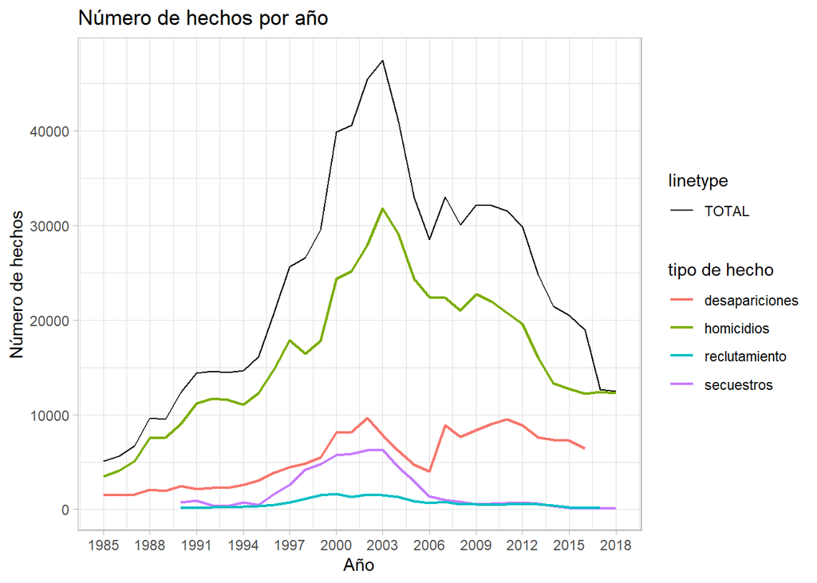

```r
#plot total per year

ggplot(homicides_per_year, aes(x = yy_hecho, y = n, color = "homicidios")) +
  geom_line(data = total_per_year, aes(x = yy_hecho, y = total, linetype = "TOTAL"),color="black")+
  geom_line(size =0.8) +
  geom_line(data = disappearance_per_year, aes(x = yy_hecho, y = n, color = "desapariciones"),size=0.8)+
  geom_line(data = kidnapping_per_year, aes(x = yy_hecho, y = n, color = "secuestros"),size=0.8)+
  geom_line(data = recruitment_per_year, aes(x = yy_hecho, y = n, color = "reclutamiento"),size=0.8)+
  labs(title = "Número de hechos por año",
       x = "Año",
       y = "Número de hechos",
       color = "tipo de hecho") +
  theme_light() +
  scale_x_continuous(breaks = seq(min(homicides_per_year$yy_hecho), max(homicides_per_year$yy_hecho), by = 3))
```

En esta gráfica se puede observar que el eje “x” representa el avance de los años y el eje “y” representa el numero de hechos respecto al año. La linea negra representa el total de hechos y las demás lineas representan la tendencia de los hechos individualmente. De esta tendencia se observa que todos los hechos se comportan de manera similar a lo largo de los años siguiendo usualmente la misma tendencia. De esta tendencia se observa que, para todos los hechos, durante el periodo comprendido entre el año 1994 y 2003, la tendencia de hechos violentos fue en su mayoría creciente y, en el periodo comprendido entre 2003 y 2006 hubo un decrecimiento para todos los hechos. Este decrecimiento en la violencia se le puede atribuir a diversos factores como la desmovilización de grupos paramilitares que , coincide históricamente con la época de decrecimiento en la gráfica. Sin embargo es importante considerar que estas tendencias pueden deberse a varios factores y bajo ningún concepto deben atribuirsele a uno solo de ellos.

El hecho que ocurrió con mas frecuencia según la gráfica fue el homicidio estando mas cerca en números al total de los hechos que al segundo hecho mas frecuente. Es importante entender que, muy probablemente, todos estos hechos tienen una relación directa entre ellos, dado que se habla de incremento de la violencia es comprensible que todos los hechos sigan la misma tendencia, así como se puede considerar que la tendencia entre los hechos indica relación entre los mismos.

### 4.3.2 Hechos por grupo

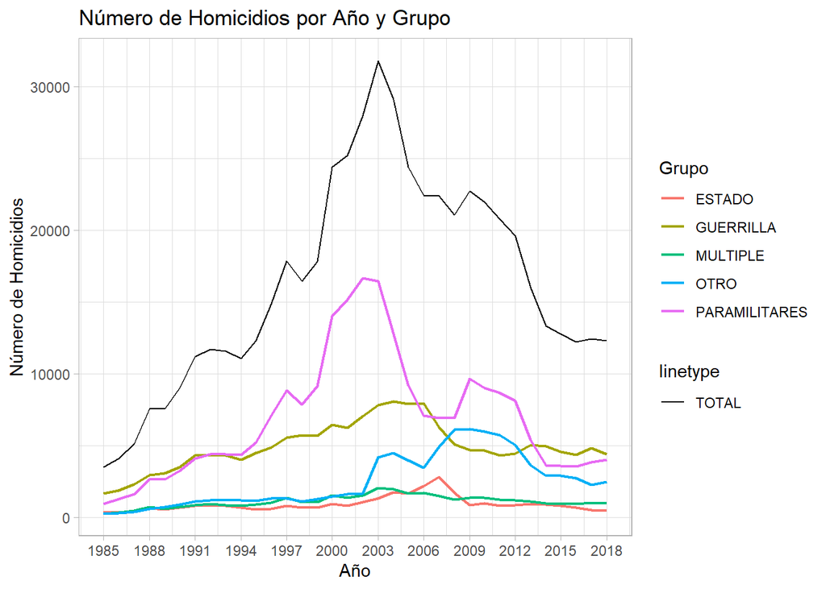

```r
#plot homicides_per_group

ggplot(homicides_per_group, aes(x = yy_hecho, y = n, color = Grupo)) +
  geom_line(size =0.8) +
  geom_line(data = homicides_per_year, aes(x = yy_hecho, y = n, linetype = "TOTAL"),color="black")+
  labs(title = "Número de Homicidios por Año y Grupo",
       x = "Año",
       y = "Número de Homicidios",
       color = "Grupo") +
  theme_light() +
  scale_x_continuous(breaks = seq(min(homicides_per_group$yy_hecho), max(homicides_per_group$yy_hecho), by = 3))
```

En la gráfica de homicidios por grupo la linea negra representa el total de homicidios en función del año y el resto de lineas representan el numero de homicidios realizados por diversos grupos en función del año.

El grupo que más homicidios realizó fueron los paramilitares, seguidos de las guerrillas. Este resultado implica que, tal como se concibe en la cultura popular, los paramilitares solían ser mas propensos a cometer homicidios que los demás grupos.

Tambien se puede observar que, cuando el numero de homicidios por parte de los paramilitares y las guerrillas empezó a disminuir, el numero de homicidios realizados por otros grupos al margen de la ley aumentó. Este aumento se puede deber a disidencias o otros grupos que se crearon tras las desmovilización de los paramilitares entre 2003 y 2006, ya que se puede considerar que un evento como la desmovilización de un agente del conflicto implica cosas como nuevos agentes del mismo.

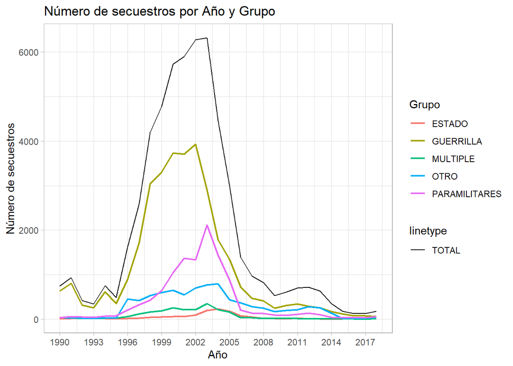

```r
ggplot(kidnapping_per_group, aes(x = yy_hecho, y = n, color = Grupo)) +
  geom_line(size =0.8) +
  geom_line(data = kidnapping_per_year, aes(x = yy_hecho, y = n, linetype = "TOTAL"), color="black")+
  labs(title = "Número de secuestros por Año y Grupo",
       x = "Año",
       y = "Número de secuestros",
       color = "Grupo") +
  theme_light() +
  scale_x_continuous(breaks = seq(min(kidnapping_per_group$yy_hecho), max(kidnapping_per_group$yy_hecho), by = 3))
```

En la gráfica de secuestros por grupo la linea negra representa el total de Secuestros en función del año y el resto de lineas representan el numero de secuestros realizados por diversos grupos en función del año.

Se puede observar que, tal como sugiere el ideario colectivo, las guerrillas son el grupo que mas secuestros realiza, encabezando la tendencia en la gráfica, seguidos por los paramilitares y otros grupos.

En este caso especifico se puede decir que la tendencia del total de secuestros se parece bastante a la tendencia de los secuestros cometidos por las guerrillas, demostrando así que las guerrillas fueron mas propensas a realizar secuestros siendo que la mayoría de los secuestros fueron realizados por las mismas. Estas cifras pueden indicar que las guerrillas lideraron en este apartado dado a que los secuestros eran uno de los mayores medios de ingresos para las guerrillas.

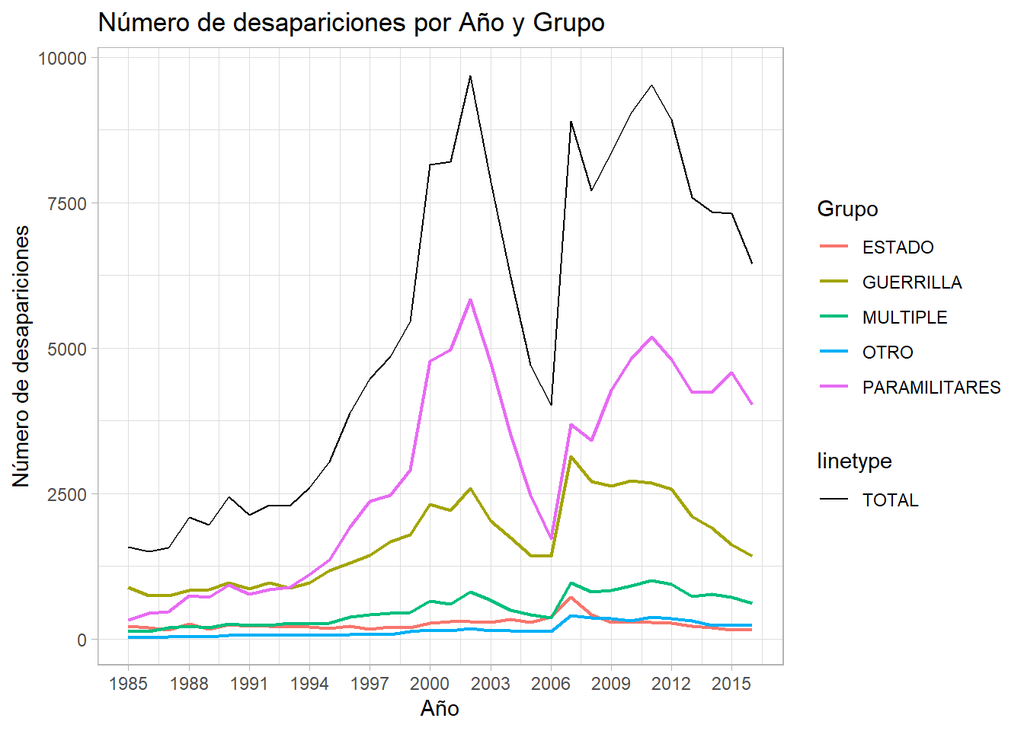

```r
#plot disappearence_per_group

ggplot(disappearance_per_group, aes(x = yy_hecho, y = n, color = Grupo)) +
  geom_line(size =0.8) +
  geom_line(data = disappearance_per_year, aes(x = yy_hecho, y = n, linetype = "TOTAL"),color="black")+
  labs(title = "Número de desapariciones por Año y Grupo",
       x = "Año",
       y = "Número de desapariciones",
       color = "Grupo") +
  theme_light() +
  scale_x_continuous(breaks = seq(min(disappearance_per_group$yy_hecho), max(disappearance_per_group$yy_hecho), by = 3))
```

En la gráfica de desapariciones por grupo la linea negra representa el total de desapariciones en función del año y el resto de lineas representan el numero de desapariciones realizados por diversos grupos en función del año.

A pesar de que en el periodo comprendido entre el año 2003 y el año 2006 la tendencia de desapariciones decrece, el comportamiento de la gráfica se torna relativamente diferente al de las demás gráficas ya que mas adelante hay periodos con un crecimiento masivo de las cifras.

El grupo armado al que se le atribuyen mayor numero de desapariciones vendrían siendo los paramilitares, seguidos por los grupos guerrilleros.

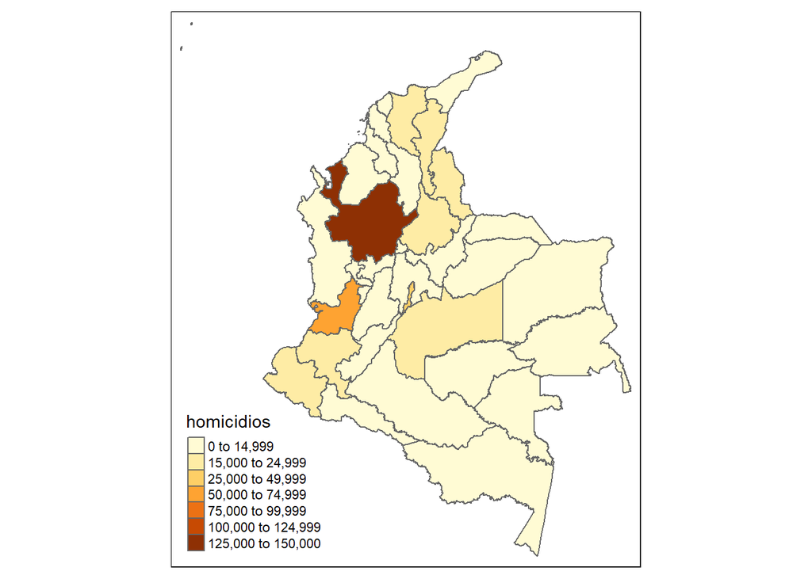

```r
#mapa homicidios historico por municipio
map <- st_read("Mapas_dept/DepartamentosVeredas.shp") #cargar el mapa

#Acomodar las columnas del dataframe
homicides_group_dept$DPTO_CCDGO<-factor(homicides_group_dept$dept_code_hecho)
homicides_group_dept$dept_code_hecho<-NULL
homicides_group_dept$homicidios<-homicides_group_dept$n
homicides_group_dept$n<-NULL

map <- map[,c(1,2)]

#unir las coordenadas del mapa con el dataframe

map <- left_join(map, homicides_group_dept)

summary(map)
#graficar
qtm(map,"homicidios", fill.breaks = c(0,15000,25000, 50000,75000,100000,125000,150000))
```

En este gráfico se muestra un mapa de calor por departamentos en función de ciertos intervalos que representan el número de homicidios a lo largo de la historia del país.

En este mapa se puede observar como Antioquia es el departamento con mayor número de homicidios con más de 125000 homicidios registrados en su historia, también se observa que el segundo departamento con mayor número de homicidios fué Valle del Cauca con más de 50000 homicidios. Adicional a esto se observa que la zona norte del país tuvo un mayor índice de homicidios que el resto del país

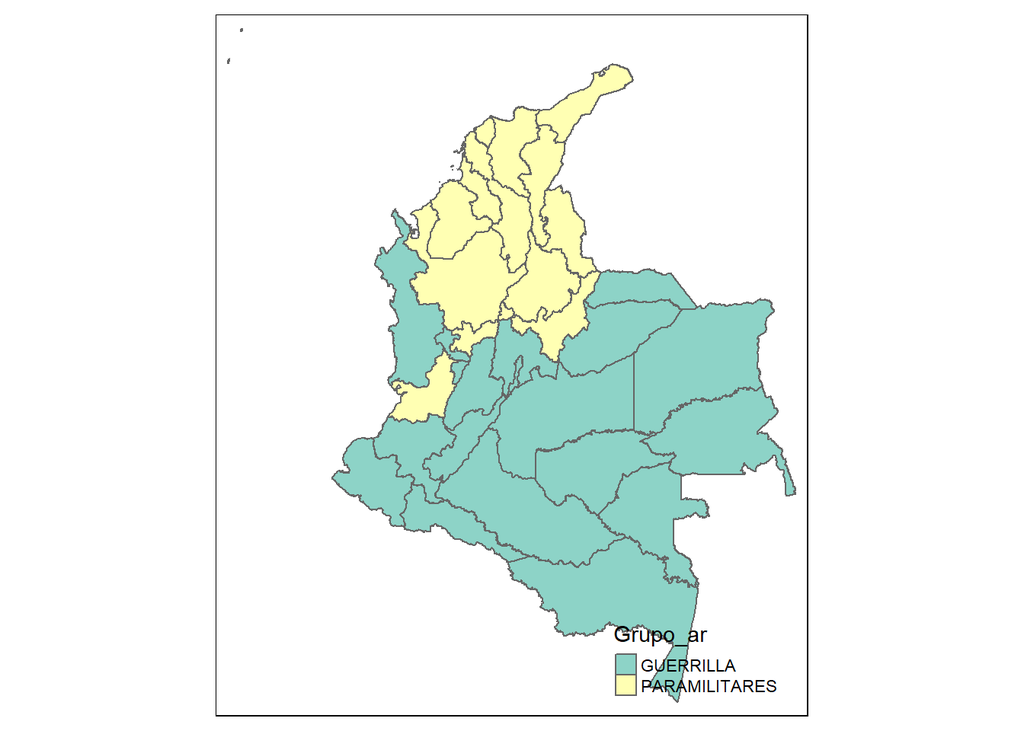

```r
map2 <- st_read("Mapas_dept/DepartamentosVeredas.shp") #cargar mapas

#Acomodoar columnas
homicides_per_group_dept$DPTO_CCDGO<-factor(homicides_per_group_dept$dept_code_hecho)
homicides_per_group_dept$dept_code_hecho<-NULL
homicides_per_group_dept$Grupo_ar<-homicides_per_group_dept$Grupo
homicides_per_group_dept$Grupo<-NULL

map2 <- map2[,c(1,2)]

map2 <- left_join(map2, homicides_per_group_dept)

#graficar por grupo
tm_shape(map2) +
  tm_borders() +
  tm_fill("Grupo_ar", palette = "Set3") +
  tm_layout(legend.position = c("right", "bottom"))
```

En este gráfico se hizo una representación binaria, comparando las cifras que se le atribuyen a grupos paramilitares con las que se le atribuyen a las guerrillas. Los departamentos en verde son aquellos en los que las guerrillas tienen mayor cifra de homicidios que los paramilitares, y los departamentos en amarillo son aquellos en los que los paramilitares alcanzaron mayores cifras que las guerrillas.

Si bien la zona que corresponde a grupos paramilitares en el mapa, al compararla con el mapa de calor, tiene mayores cifras de homicidios, las guerrillas tienen mayor impacto en mayor número de departamentos

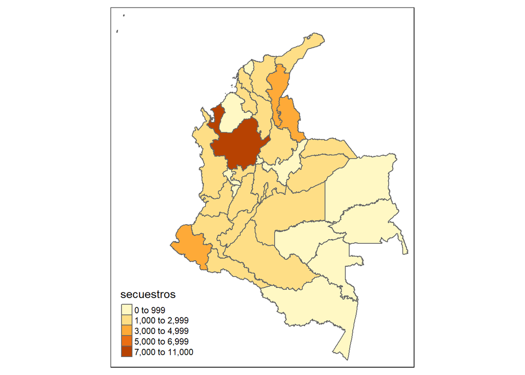

```r
map3 <- st_read("Mapas_dept/DepartamentosVeredas.shp") #cargar mapa

#acomodar columnas
kidnapp_group_dept$DPTO_CCDGO<-factor(kidnapp_group_dept$dept_code_hecho)
kidnapp_group_dept$dept_code_hecho<-NULL
kidnapp_group_dept$secuestros<-kidnapp_group_dept$n
kidnapp_group_dept$n<-NULL

map3 <- map3[,c(1,2)]

map3 <- left_join(map3, kidnapp_group_dept)

summary(map3)

#graficas
qtm(map3,"secuestros", fill.breaks = c(0,1000,3000, 5000,7000,11000))
```

En este grafico se muestra un mapa de calor por departamentos en función de ciertos intervalos que representan el número de Secuestros a lo largo de la historia del país.

Se puede observar como una vez más Antioquia es el departamento más afectado. En este caso el mapa de calor presenta mayor uniformidad, sin embargo el norte del país sigue teniendo un gran número de casos con respecto al resto de país.

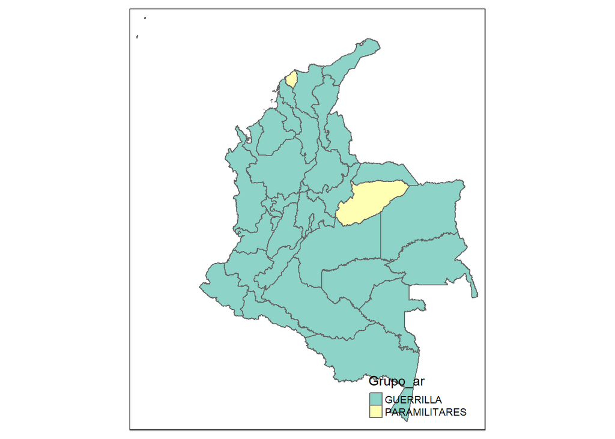

```r
map4 <- st_read("Mapas_dept/DepartamentosVeredas.shp") #cargar mapa

#acomodar columnas

kidnapp_per_group_dept$DPTO_CCDGO<-factor(kidnapp_per_group_dept$dept_code_hecho)
kidnapp_per_group_dept$dept_code_hecho<-NULL
kidnapp_per_group_dept$Grupo_ar<-kidnapp_per_group_dept$Grupo
kidnapp_per_group_dept$Grupo<-NULL

map4 <- map4[,c(1,2)]

map4 <- left_join(map4, kidnapp_per_group_dept)

#graficas
tm_shape(map4) +
  tm_borders() +
  tm_fill("Grupo_ar", palette = "Set3") +
  tm_layout(legend.position = c("right", "bottom"))
```

En este grafico se hizo una representación binaria, comparando las cifras que se le atribuyen a grupos paramilitares con las que se le atribuyen a las guerrillas. Los departamentos en verde son aquellos en los que las guerrillas tienen mayor cifra de secuestros que los paramilitares , y los departamentos en amarillo son aquellos en los que los paramilitares alcanzaron mayores cifras que las guerrillas.

Se puede observar como las guerrillas tienen mayor impacto en el mapa en tema de secuestros que los paramilitares, siendo que , los paramilitares solo tuvieron más impacto que las guerrillas en dos departamentos.

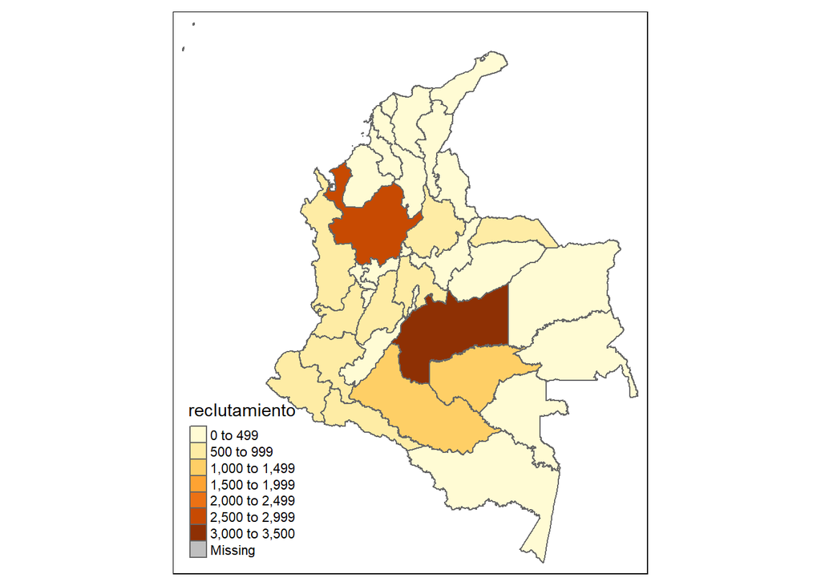

```r
map5 <- st_read("Mapas_dept/DepartamentosVeredas.shp")

recruitment_group_dept$DPTO_CCDGO<-factor(recruitment_group_dept$dept_code_hecho)
recruitment_group_dept$dept_code_hecho<-NULL
recruitment_group_dept$reclutamiento<-recruitment_group_dept$n
recruitment_group_dept$n<-NULL

map5 <- map5[,c(1,2)]

map5 <- left_join(map5, recruitment_group_dept)

summary(map5)

qtm(map5,"reclutamiento", fill.breaks = c(0,500,1000, 1500,2000,2500,3000,3500))
```

En este gráfico se muestra un mapa de calor por departamentos en función de ciertos intervalos que representan el número de reclutamientos a lo largo de la historia del país.

Se puede observar como Antioquia es un departamento en el que suelen haber muchos reclutamientos, sin embargo, el departamento con mayor número de reclutamientos fué el Meta. Además se puede observar como la zona centro-sur del país fue la que se vió mas afectada para este caso.

### 4.3.3 Secuestros que llevan a homicidios

Hay una relación entre varios registros de diferentes dataframes de un mismo grupo por id.

Tomando estos datos y los datos totales se puede decir que cerca del 12% de los secuestros efectuados por las guerrillas terminan en homicidios mientras que cerca del 28% de secuestros realizados por los paramilitares terminan en homicidios

A continuacion se muestra la respectiva tabla.

```r
kidnapp_homicidie <-inner_join(homicide1df, kidnapping1df, by = "match_group_id")

kidnapping_homicide_per_group <- kidnapp_homicidie %>%
  mutate(Grupo = case_when(


    grepl("GUE",p_str.x) ~ "GUERRILLA",
    grepl("PARA",p_str.x) ~ "PARAMILITARES",
    grepl("EST",p_str.x) ~ "ESTADO",
    grepl("multiple",p_str.x) ~ "MULTIPLE",
    TRUE ~ "OTRO"
  )) %>%
  group_by(yy_hecho.x,Grupo) %>%
  summarise(n=n())
```

El dataframe generado muestra el numero de secuestros que terminaron en homicidio por parte de Las guerrillas y los paramilitares a lo largo de la historia.

| yy_hecho.x | Grupo | n |
| --- | --- | --- |
| 1990 | ESTADO | 1 |
| 1990 | GUERRILLA | 17 |
| 1990 | MULTIPLE | 8 |
| 1990 | OTRO | 5 |
| 1990 | PARAMILITARES | 12 |
| 1991 | ESTADO | 8 |

# 5 Conclusiones

## 5.1 Datos por año

En general la violencia en el margen del conflicto armado aumentó hasta llegar a su punto máximo en el año 2003 para luego decrecer. De esto se pueden decir varias cosas:

1. Se desconoce si en los primeros años registrados en los datasets se omitió información, ya sea por las limitaciones de la época para mantener registros de los datos o contexto social.
2. Al decrecimiento de las tendencias se le pueden atribuir distintos factores, pero un factor considerable puede ser la desmovilización de los paramilitares entre 2003 y 2006.

El homicidio fue el hecho mas frecuente a lo largo de los años, siendo tan frecuente que se acerca mas al total de los hechos que al segundo hecho mas frecuente.

## 5.2 Datos por grupo

- En lo que respecta a homicidios y desapariciones los paramilitares tuvieron las mayores cifras. Este numero de cifras respalda la creencia popular sobre el hecho de que los paramilitares eran mas propensos a cometer homicidios.
- En lo referente a secuestros las guerrillas tuvieron mayores cifras que los paramilitares y cualquier otro grupo. Esto indica que la creencia popular de que las guerrillas son propuestas a realizar secuestros es acorde a los datos tomados. Ademas se puede complementar esta información con los hechos históricamente conocidos de que las guerrillas encontraban financiamiento en los secuestros
- Como se mencionó en el inciso anterior, la desmovilización de los paramilitares pudo ser un factor muy influyente en la disminución de la violencia, Sin embargo, cuando ocurrió este hecho y en ese mismo aumentaron los hechos atribuidos a otros grupos desconocidos. Estos grupos desconocidos pueden ser tantos disidencias como nuevos grupos que surgieron tras el vacío de participación de los paramilitares.

## 5.3 Datos por departamento

En este caso ocurrió algo sorpresivo en lo que respecta a secuestros y homicidios se puede decir que las guerrillas tuvieron mas impacto en el país que los paramilitares, por lo tanto se puede hallar una explicación sobré porqué existe mayor rechazo hacia las guerrillas que hacia los paramilitares. Entonces cabe preguntarse ¿Porqué si las guerrillas tuvieron mayor impacto en un numero de departamentos los paramilitares tienen mayores cifras en lo que respecta a hechos violentos?, la respuesta radica en que, aunque las guerrillas tuvieron predominancia en la mayoría de departamentos y ,en tema de secuestros tuvieron predominancia en casi todo el país, los paramilitares tuvieron cifras demasiado elevadas en los departamentos en los que tuvieron predominancia como por ejemplo el departamento de Antoquia, el cual podría ser considerado “zona roja” , dado que fue el departamento con mayor indice de violencia entre todos los departamentos.

Sobre los secuestros que llevan a homicidios se pueden decir dos cosas:

1. Si bien las guerrillas eran mas propensas a cometer secuestros, es mas probable que ese secuestro no lleve a un homicidios que un secuestro realizado por paramilitares.
2. En cuestión de cifras los secuestros que llevan a homicidios no representan gran parte de los hechos, siendo que solo 9200 secuestros terminaron en homicidios.

## 5.4 Informacion que no cubre este informe.

- No se consideró ni el sexo ni la etnia.
- No se considerarón las imputaciones de la JEP puesto que no es el objetivo del informe.
- Se desconocen las limitaciones del conjunto de datos

# 6 Referencias

Datos del DANE

- [Link a hipervinculo] (https://microdatos.dane.gov.co/index.php/catalog/795)